# Assignment 2 - Social Data Science

Group 15

November 9, 2015

## **Scrape & Analysis of www.ipaidabribe.com**

We are to scrape the website and clean the gathered data primarily using the R-packages: *stringr*, *plyr*, *dplyr* & *rvest*. Then, we will delve into a very light econometric analysis paired with geo-spatial data-analysis using *ggplot*, *countrycode* etc.

### **Scraping the [website](http://ipaidabribe.com/reports)**: Steps 1-2

The website is constructed in a way such that for each page of recorded bribes contains 10 posts per page. It did not prove useful to use selector-gadget for identifying the underlying html-table. However, any page of 10 posts only has unique URL-element; http://www.ipaidabribe.com/reports/paid?page={**any integer**}. Thus, we took the following approach: create vector of integers from 0:1000 in intervals of 10. Insert 0, 10, 20 etc. into the element in URL that determines page number via loop - here looping with plyr was deemed useful as it is simple to coerce into dataframe and is rather fast.

```r
head(num.link.li2, 5)
```

```
## [1] "http://www.ipaidabribe.com/reports/paid?page=0"
## [2] "http://www.ipaidabribe.com/reports/paid?page=10"
## [3] "http://www.ipaidabribe.com/reports/paid?page=20"
## [4] "http://www.ipaidabribe.com/reports/paid?page=30"
## [5] "http://www.ipaidabribe.com/reports/paid?page=40"
```

We have now obtained 100 pages each containing 10 posts. Directly from these pages, the post-information we are interested in is accessible, given the appropriate CSS-selectors:

```r
## Let's identify the relevant css-selectors

as2.css.selector_1 = ".heading-3 a"       #URL and/or TITLE depends on 'html_attr(name = href/title)'
as2.css.selector_2 = "span.date"          #date
as2.css.selector_3 = "li.paid-amount"     #amount paid
as2.css.selector_4 = "div.key > a"        #location
as2.css.selector_5 = "li.name > a"        #department
as2.css.selector_6 = "li.transaction > a" #transaction details
as2.css.selector_7 = "li.views"           #number of views
```

Defining function and creating loop for iterating trhough all observations in **num.link.li2**. We make use of **rvest** in order to fetch data.

### **Cleaning gathered data, preparation & external data** : Step 3-4

When the 1.000 posts have been obtained, we coerce from list into a dataframe using *ldply([data], data.frame)*. From here we need to do basic data-cleaning primarily utilizing functions contained in *stringr* in order to have a tidy, interpretable dataframe.

It may prove insightful to add additional data to the existing dataframe. One factor explaining differences in the amount of posts to the website may be internet accessibility. Users of the website need an access-point, most likely a smartphone or laptop - whether or not an individual is able to properly use such a device may, in turn, depend on literacy. Literacy can also serve as an indirect indicator of earnings-potential; literacy is often thought of as an asset in the labour market. Here, data from wikipedia on literacy in India is used - imported as .csv:

## **Analysis**

Exploring geographical and time-dependent relationships within the generated data-frame

### **Mapping geo-spatial data**: Step 5

In order to visualize discrepancies in post-views and bribes paid across cities in India, a map seems ideal. The *ggmap*-package allows for visualizations using Googles Maps service for plotting overlays on top. Using the *maps*-package we fetch the geo-coordinates needed.

This map illustrates population and views of posts by city:

[figure not shown]

```r
plot(ind)
```

We clearly see, that a substantial number of cities have a relatively large fraction of post-views compared to population, i.e. the blue dots are non-transparent compared to the orange ones. This could indicate a multitude of things. However, if we assume that individuals reading the posts are primarily interested in their local area’s level of corruption and don’t view posts based on other criteria, one might argue that the number of users of the website is not evenly distributed amongst indian cities. This indicates that causal analysis using cross-sectional econometric tools may not be a viable approach, as the random sample assumption of most linear regression strategies is likely to be violated. This being said, other approaches for extrapolating insights from the data still exist.

### **Other data visualizations**: Step 6

Given the above reasoning, looking at time-dependency in the usage of the website. Extracting weekdays. Setting OS-derived locale to english in order to get english weekdays.

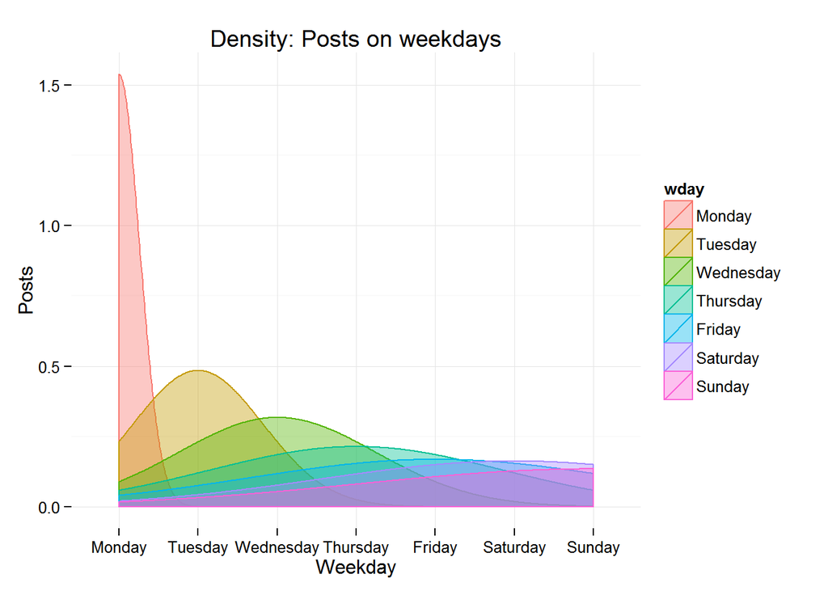

```r
plot(wp)
```

Apparently mondays are popular. We will investigate, what drives this tendency; geographical or departmental.

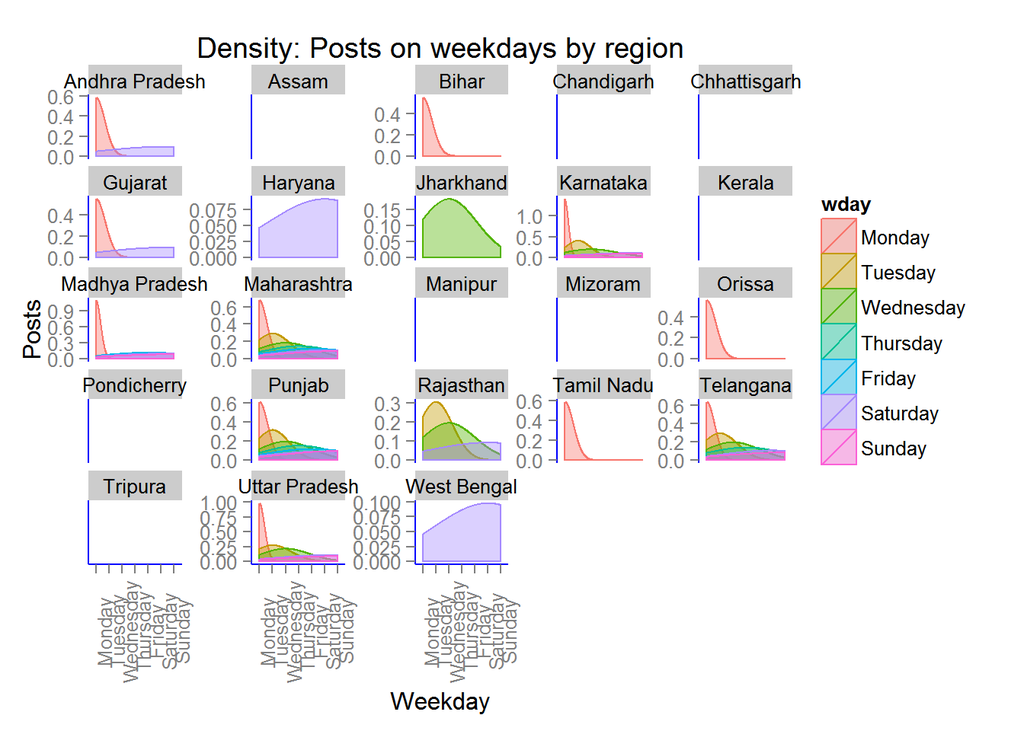

```r
plot(ep)
```

Some regions seem to be following the overall trend, however others only post on e.g. saturdays - maybe we should pick out the most populous, as the differences in population between these are rather large. The larger regions appear to be more representative in terms of this particular tendency.

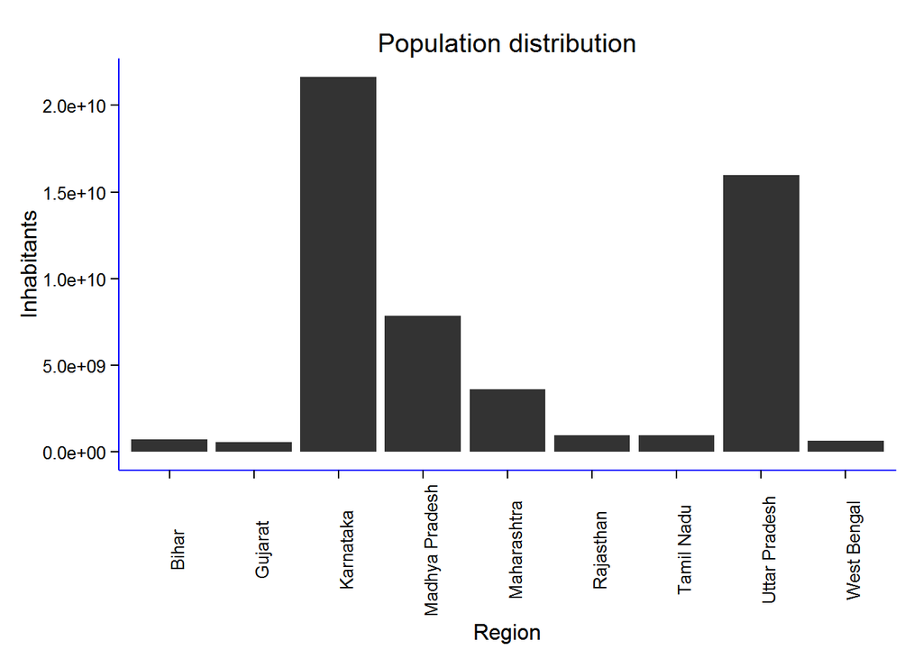

```r
plot(pl)
```

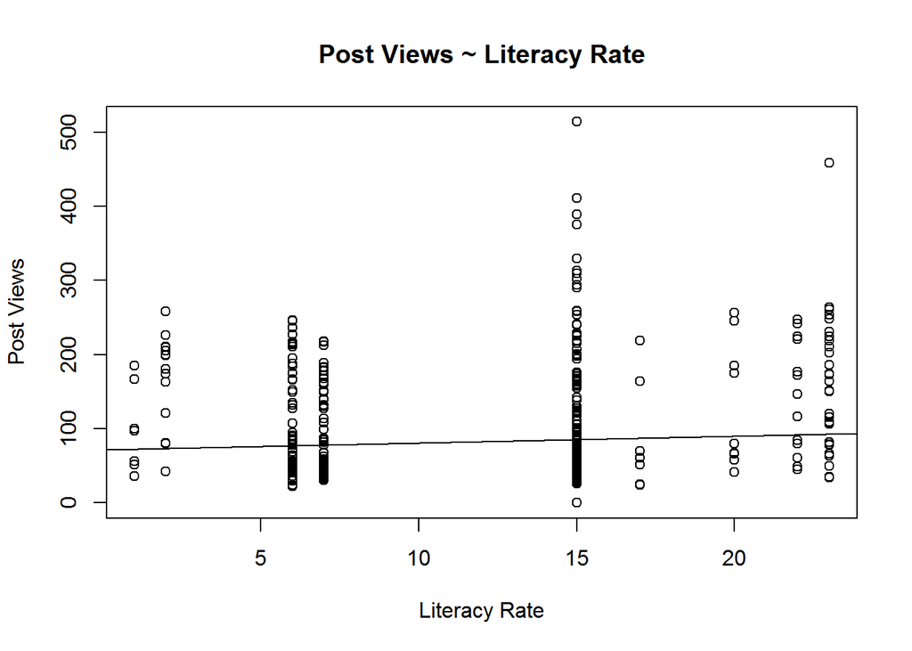

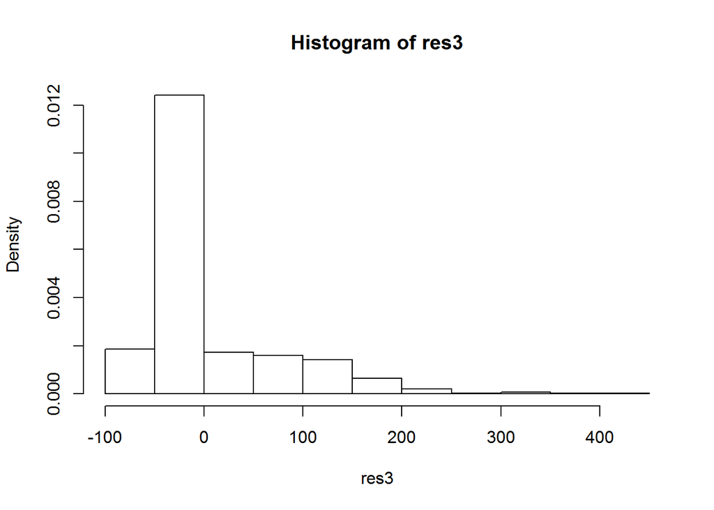

The relationship seems dubious, however stronger than when not subsetting the dataframe to 50M+ regions.

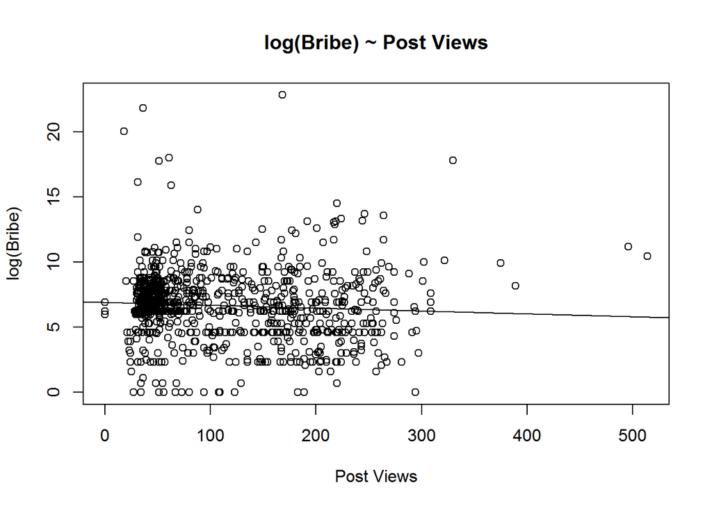

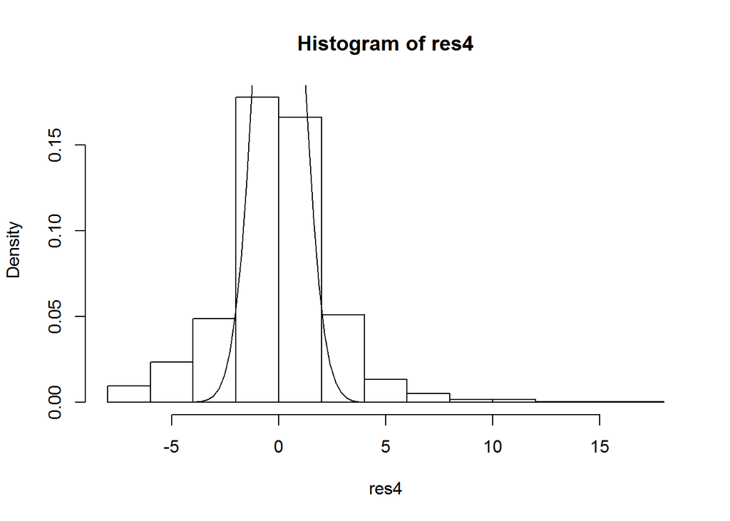